# EDH similarities per province and dates

#### *with restricted multiple imputation*

03 november 2021

### Preliminaries

`R` packages installation and load.

```r
# package "sdam" beta version
devtools::install_github("mplex/cedhar", subdir="pkg/sdam")
# dependencies
install.packages("multiplex")
install.packages("multigraph")
```

```r
# load and check versions
library(sdam)
packageVersion("sdam")
```

```
[1] '0.7.3'
```

```r
library(multigraph)
packageVersion("multigraph")
```

```
[1] '0.96.2'
```

```r
packageVersion("multiplex")
```

```
[1] '2.9.6'
```

### Variable attributes

Load `EDH` data set and define the two variables of interest where network imputation comes plus other variable attributes of interest.

```r
# EDH data set
data("EDH")
```

```r
# for imputation
dates = c("not_before", "not_after")
# characteristics
vars = c("findspot_ancient", "type_of_inscription", "type_of_monument", "language")
```

- `edhv` is a data frame that records the chosen variables from `EDH`.

```r
# EDH dataset as a dataframe with variables
edhv = sdam::edhw(vars=c(dates, vars, "province_label"), as="df")
```

- `edhvp` is a list of data frames per province.

```r
# load province names and acronyms as in EDH
data("rp")
edhvprov <- list()
for(i in names(rp)) {
    edhvprov[[length(edhvprov)+1L]] <- edhw(edhv, province=i)
};rm(i)
names(edhvprov) <- names(rp)
```

…and where the number of inscriptions per province is computed.

```r
# Dalmatia has largest amount of inscriptions
sort(unlist(lapply(edhvprov, nrow)), decreasing=TRUE)
```

```
 Dal  GeS  HiC  Bri  Afr  PaS  Rom  Dac  GeI  PaI  Bae  Nor  Num  LaC  MoI  Bel  Lus  MoS  Mak  Nar
7711 7024 5221 4561 4496 4384 4331 3682 3352 3240 3035 2789 2642 2606 2073 1691 1577 1515 1409 1403
 Ach  VeH  MaC  Rae  ApC  Etr  Sam  Lug  Asi  AlC  Aqu  AlM  Thr  Syr  Umb  BiP  MaT  BrL  Ara  Aem
1328 1161 1127 1017  760  671  648  597  491  476  427  416  411  403  348  293  291  246  234  231
 Sar  Gal  AlP  Sic  Iud  Bar  Tra  Aeg  Pic  Lig  Epi  Cyr  Cil  ReB  AlG  Cre  Cap  LyP  Cor  Cyp
 229  211  206  193  192  189  180  172  170  153  144   90   86   78   77   66   63   59   46   35
 Mes  Arm  Ass  Inc  Tri  Val
  12    3    0    0    0    0
```

### Similarity example

Organize similarities in Roman province of Aegyptus according to attributes defined in `vars` (that by default includes `dates`).

```r
aeg = sdam::edhw(x=edhv, vars=c(dates, vars), province="Aeg")
```

```
           id     type_of_monument        type_of_inscription not_before not_after    language
741  HD000741                cliff identification inscription       0001      0200       Latin
2003 HD002003 architectural member identification inscription      -0116      <NA> Greek-Latin
3126 HD003126              diptych                       <NA>       0101      0200       Latin
6782 HD006782                 <NA>                       <NA>       0212      0250       Latin
6785 HD006785                 <NA>                       <NA>       0200      0250       Latin
8142 HD008142               tabula                    epitaph       0065      <NA>       Latin
     findspot_ancient
741              <NA>
2003           Philae
3126             <NA>
6782       Alexandria
6785       Alexandria
8142       Alexandria
```

### Example with people

```r
# characteristics + people
varsp <- c("people","findspot_ancient", "type_of_inscription", "type_of_monument", "language")

# EDH dataset as a dataframe with variables + people
edhvp <- edhw(vars=c(dates, varsp, "province_label"), select=c("tribus","origo","nomen"), as="df")
```

```r
# Aegyptus with people
aegp <- edhw(x=edhvp, province="Aeg")
```

```
           id   tribus origo    nomen     type_of_monument        type_of_inscription
1932 HD000741     <NA>  <NA>     <NA>                cliff identification inscription
4671 HD002003 Teretina  <NA> Acutius+ architectural member identification inscription
4672 HD002003     <NA>  <NA>   Fabius architectural member identification inscription
4673 HD002003     <NA>  <NA> Licinius architectural member identification inscription
4674 HD002003     <NA>  <NA> Claudius architectural member identification inscription
4675 HD002003     <NA>  <NA>  Varaeus architectural member identification inscription
     province_label not_before not_after    language findspot_ancient
1932       Aegyptus       0001      0200       Latin               NA
4671       Aegyptus      -0116        NA Greek-Latin           Philae
4672       Aegyptus      -0116        NA Greek-Latin           Philae
4673       Aegyptus      -0116        NA Greek-Latin           Philae
4674       Aegyptus      -0116        NA Greek-Latin           Philae
4675       Aegyptus      -0116        NA Greek-Latin           Philae
```

… with `people`, e.g., just record `HD002003` has 5 *nomen*…

#### Network approach

Then we proceed by creating a similarity matrix `maeg` on the chosen attribute variables.

```r
# adjacency matrix
maeg <- simil(aeg, vars=vars)
```

and look at the first 10 entries

```r
maeg[1:10,1:10]
```

```
         HD000741 HD002003 HD003126 HD006782 HD006785 HD008142 HD008673 HD011661 HD011887 HD012418
HD000741        0        1        1        1        1        1        1        1        1        1
HD002003        1        0        0        0        0        0        0        0        0        0
HD003126        1        0        0        1        1        1        1        1        1        1
HD006782        1        0        1        0        2        2        1        1        1        1
HD006785        1        0        1        2        0        2        1        1        1        1
HD008142        1        0        1        2        2        0        1        1        1        1
HD008673        1        0        1        1        1        1        0        1        1        1
HD011661        1        0        1        1        1        1        1        0        1        1
HD011887        1        0        1        1        1        1        1        1        0        1
HD012418        1        0        1        1        1        1        1        1        1        0
```

None of the above inscriptions have all attributes in common; however some epigraphical material have in this data set.

```r
max(maeg)
```

```
[1] 4
```

We proceed by creating subsets of inscriptions having all characteristics in common, which means that the most similar inscriptions form *cliques*.

```r
# dichotomize and remove isolates
mdaeg <- rm.isol(dichot(maeg,c=max(maeg)))
```

and look at the graph of these cliques.

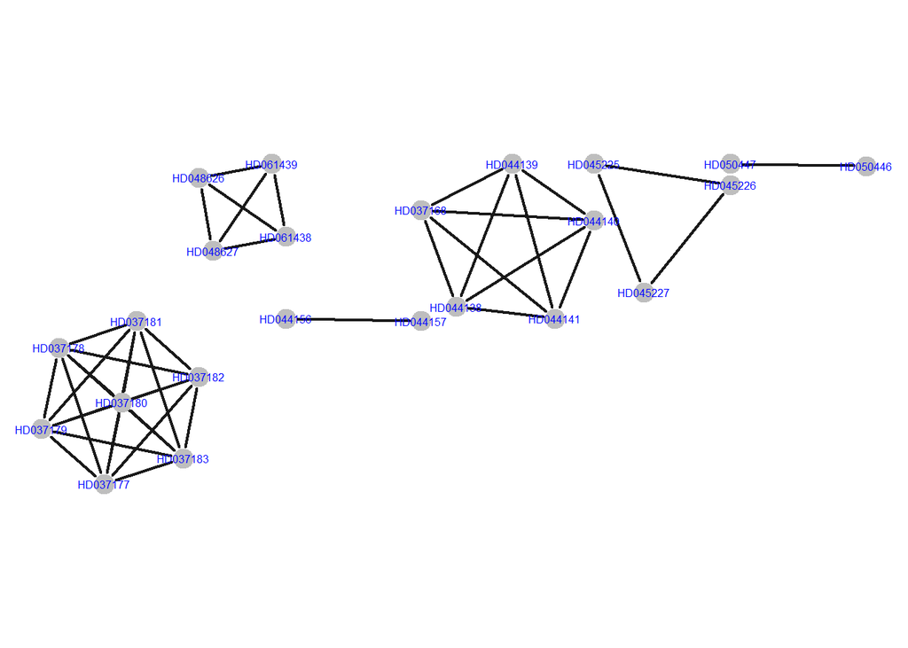

Cliques of Aegyptian inscriptions

```r
# define the scope
scp <- list(directed=FALSE, valued=TRUE, pos=0, col=8, fcol="blue", cex=2)
# apply a force directed layout
multigraph(mdaeg, scope=scp, layout="force", seed=2)
```

#### Clique components

Clique components then constitute subsets where the imputation takes place. With the dichotomization criterion applied, the rest of inscriptions were disregarded and they become another subset of *isolates*.

We proceed by recording components ans isolates in `caeg`.

```r
# components
caeg <- comps(mdaeg)
```

```
$com
$com[[1]]
[1] "HD037168" "HD044139" "HD044140" "HD044141" "HD044138"

$com[[2]]
[1] "HD044156" "HD044157"

$com[[3]]
[1] "HD045225" "HD045226" "HD045227"

$com[[4]]
[1] "HD048626" "HD048627" "HD061438" "HD061439"

$com[[5]]
[1] "HD037177" "HD037178" "HD037179" "HD037180" "HD037181" "HD037182" "HD037183"

$com[[6]]
[1] "HD050446" "HD050447"


$isol
character(0)
```

And select items from the data set in the component

```r
sdam::edhw(aeg, id=component1)
sdam::edhw(aeg, id=component2)
```

```
            id type_of_monument type_of_inscription not_before not_after language findspot_ancient
39521 HD037168            stele             epitaph       0110      0129    Greek      Terenouthis
46474 HD044138            stele             epitaph      -0030      0100    Greek      Terenouthis
46475 HD044139            stele             epitaph       0156      0179    Greek      Terenouthis
46476 HD044140            stele             epitaph      -0011      <NA>    Greek      Terenouthis
46477 HD044141            stele             epitaph      -0026      <NA>    Greek      Terenouthis
```

```
            id type_of_monument type_of_inscription not_before not_after language findspot_ancient
46492 HD044156            block  votive inscription       <NA>      <NA>    Greek           Kellis
46493 HD044157            block  votive inscription       <NA>      <NA>    Greek           Kellis
```

### Scenes for imputation on dates

*Restricted* (or supervised) multiple imputation on dates takes place in subsets from a province data set.

For missing data in time intervals, possibilities are:

1. Cases where both TAQ and TPQ are missing, take *from the subset* if possible:
- min TAQ and max TPQ
- min TAQ plus avg length timespan
- max TPQ minus avg length timespan
- avg date

This is like the second component above in `caeg`.

2. Cases where just TPQ [TAQ] is missing:
- max TPQ [min TAQ]
- TAQ [TPQ] plus [minus] avg length timespan
- avg date?

This is like the first component above in `caeg`.

[output not shown]

[output not shown]

## Pooling

The $m$ results are pooled into final point estimates plus standard error by pooling rules.

Options for time intervals are take:

- average with avg length time-span
- min TAQ and max TPQ
- max TAQ and min TPQ

Notice that with these options there is a single imputed value per variable and information got lost.

¨

### See also

- [`"sdam"` manual](https://github.com/mplex/cedhar/blob/master/typesetting/reports/sdam.pdf)